# Rank-normalized split-Rhat and effective sample size

### 4.2.5 Scaling one chain

Next, we investigate the sensitivity to detect if one of the chains has not converged to the same distribution as the others, but has lower marginal variance.

```r
conds <- expand.grid(
  iters = c(250, 1000, 4000),
  scale = c(0, 0.25, 0.5, 0.75, 1),
  rep = 1:10
)
res <- vector("list", nrow(conds))
chains = 4
for (i in 1:nrow(conds)) {
  iters <- conds[i, "iters"]
  scale <- conds[i, "scale"]
  rep <- conds[i, "rep"]
  r <- array(rnorm(iters * chains), c(iters, chains))
  r[, 1] <- r[, 1] * scale
  rs <- as.data.frame(monitor_extra(r))
  res[[i]] <- cbind(iters, scale, rep, rs)
}
res <- bind_rows(res)
```

We first look at the Rhat estimates:

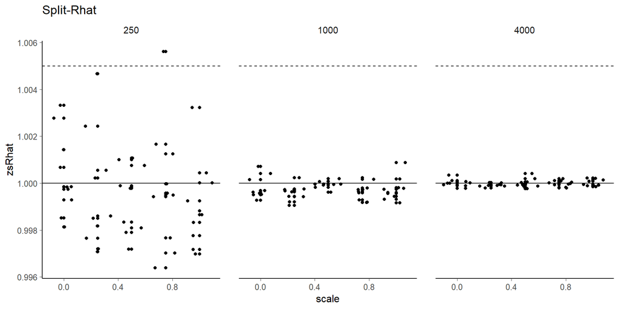

```r
ggplot(data = res, aes(y = zsRhat, x = scale)) +
  geom_point() +
  geom_jitter() +
  facet_grid(. ~ iters) +
  geom_hline(yintercept = 1.005, linetype = 'dashed') +
  geom_hline(yintercept = 1) +
  ggtitle('Split-Rhat')
```

**Result:** Split-Rhat is not able to detect scale differences between chains.

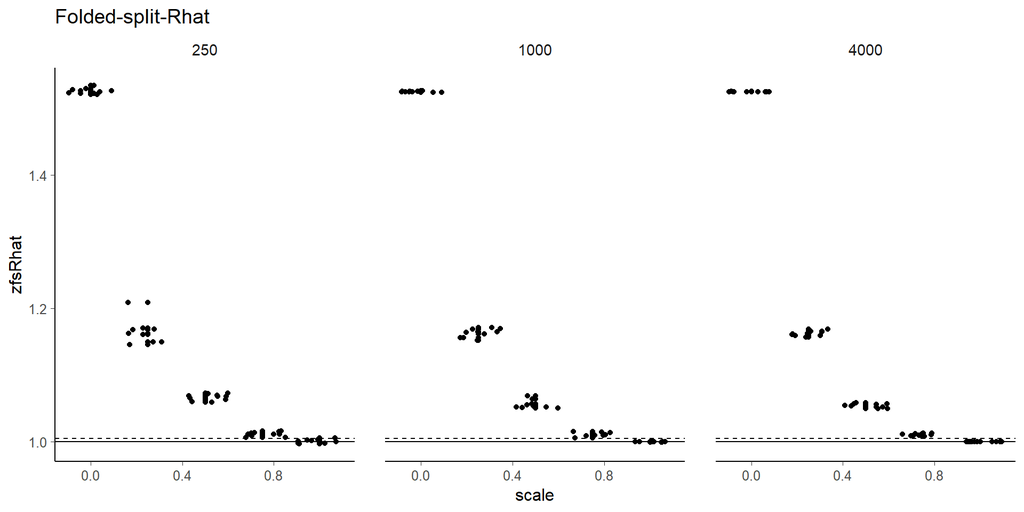

```r
ggplot(data = res, aes(y = zfsRhat, x = scale)) +
  geom_point() +
  geom_jitter() +
  facet_grid(. ~ iters) +
  geom_hline(yintercept = 1.005, linetype = 'dashed') +
  geom_hline(yintercept = 1) +
  ggtitle('Folded-split-Rhat')
```

**Result:** Folded-Split-Rhat focuses on scales and detects scale differences.

**Result:** If we use a threshold of $1.01$, we can detect a chain with scale less than $3/4$ of the standard deviation of the others. If we use threshold of $1.1$, we detect a chain with standard deviation less than $1/4$ of the standard deviation of the others.

Next, we look at the effective sample size estimates:

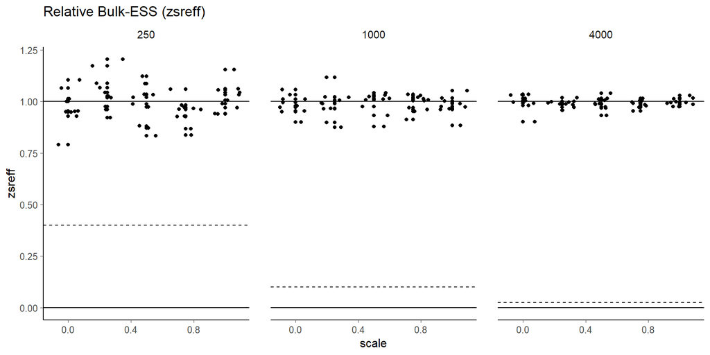

```r
ggplot(data = res, aes(y = zsreff, x = scale)) +
  geom_point() +
  geom_jitter() +
  facet_grid(. ~ iters) +
  geom_hline(yintercept = c(0,1)) +
  geom_hline(aes(yintercept = 400 / (4 * iters)), linetype = 'dashed') +
  ggtitle('Relative Bulk-ESS (zsreff)') +
  scale_y_continuous(breaks = seq(0, 1.5, by = 0.25))
```

**Result:** The bulk effective sample size of the mean does not see a problem as it focuses on location differences between chains.

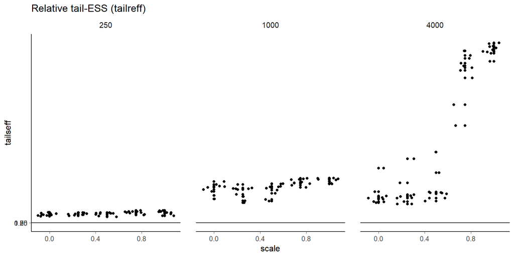

```r
ggplot(data = res, aes(y = tailseff, x = scale)) +
  geom_point() +
  geom_jitter() +
  facet_grid(. ~ iters) +
  geom_hline(yintercept = 0) +
  geom_hline(aes(yintercept = 400 / (4 * iters)), linetype = 'dashed') +
  ggtitle('Relative tail-ESS (tailreff)') +
  scale_y_continuous(breaks = seq(0, 1.5, by = 0.25))
```

**Result:** The tail effective sample size detects the difference in scales as it focuses on the scale of the chains.

Rank plots can be used to visualize differences between chains. Here, we show rank plots for the case of 4 chains, 250 draws per chain, and with one chain having a standard deviation of 0.75 as opposed to a standard deviation of 1 for the other chains.

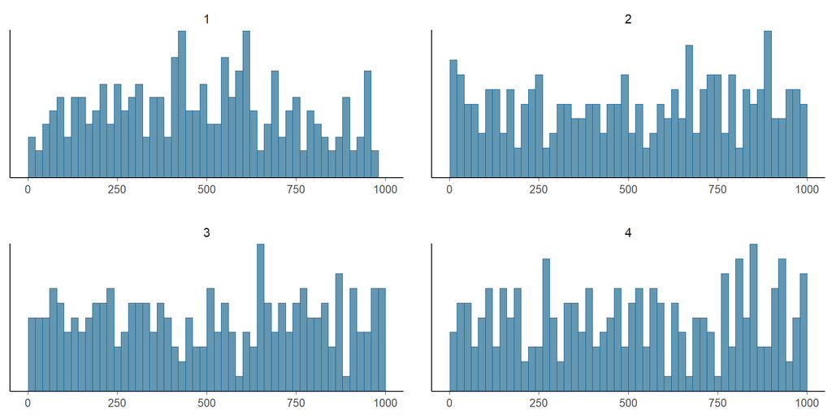

```r
iters = 250
chains = 4
scale = 0.75
r <- array(rnorm(iters * chains), c(iters, chains))
r[, 1] <- r[, 1] * scale
colnames(r) <- 1:4
mcmc_hist_r_scale(r)
```

## Appendix E: Cauchy: A distribution with infinite mean and variance

The classic split-Rhat is based on calculating within and between chain variances. If the marginal distribution of a chain is such that the variance is not defined (i.e. infinite), the classic split-Rhat is not well justified. In this section, we will use the Cauchy distribution as an example of such distribution. Also in cases where mean and variance are finite, the distribution can be far from Gaussian. Especially distributions with very long tails cause instability for variance and autocorrelation estimates. To alleviate these problems we will use Split-Rhat for rank-normalized draws.

The following Cauchy models are from Michael Betancourt’s case study [Fitting The Cauchy Distribution](https://betanalpha.github.io/assets/case_studies/fitting_the_cauchy.html)

### 4.2.6 Nominal parameterization of Cauchy

We already looked at the nominal Cauchy model with direct parameterization in the main text, but for completeness, we take a closer look using different variants of the diagnostics.

```r
writeLines(readLines("cauchy_nom.stan"))
```

```
parameters {
  vector[50] x;
}

model {
  x ~ cauchy(0, 1);
}

generated quantities {
  real I = fabs(x[1]) < 1 ? 1 : 0;
}
```

#### 4.2.6.1 Default Stan options

Run the nominal model:

```r
fit_nom <- stan(file = 'cauchy_nom.stan', seed = 7878, refresh = 0)
```

```
Warning: There were 1233 transitions after warmup that exceeded the maximum treedepth. Increase max_treedepth above 10. See
http://mc-stan.org/misc/warnings.html#maximum-treedepth-exceeded
```

```
Warning: Examine the pairs() plot to diagnose sampling problems
```

Trace plots for the first parameter look wild with occasional large values:

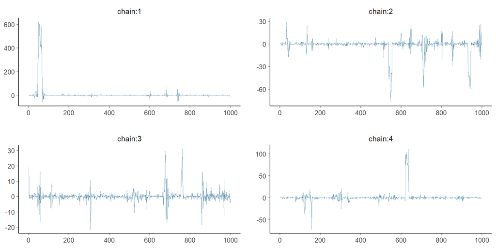

```r
samp <- as.array(fit_nom)
mcmc_trace(samp[, , 1])
```

Let’s check Rhat and ESS diagnostics.

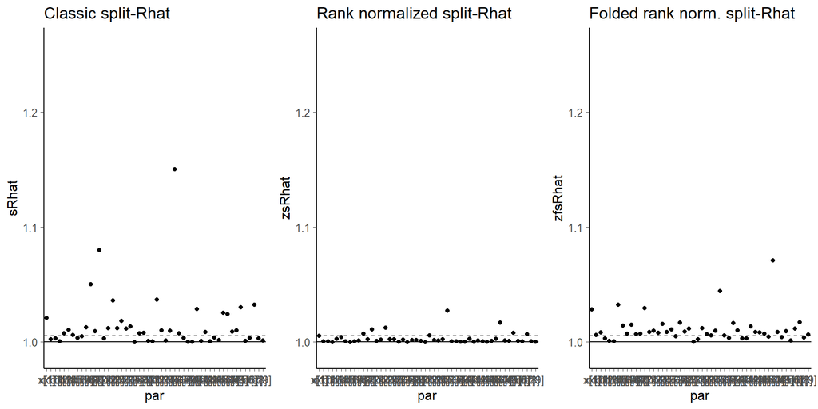

```r
res <- monitor_extra(samp[, , 1:50])
which_min_ess <- which.min(res$zsseff)
plot_rhat(res)
```

For one parameter, Rhats exceed the classic threshold of 1.1. Depending on the Rhat estimate, a few others also exceed the threshold of 1.01. The rank normalized split-Rhat has several values over 1.01. Please note that the classic split-Rhat is not well defined in this example, because mean and variance of the Cauchy distribution are not finite.

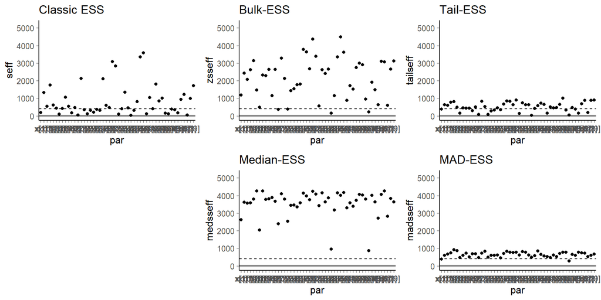

```r
plot_ess(res)
```

Both classic and new effective sample size estimates have several very small values, and so the overall sample shouldn’t be trusted.

**Result:** Effective sample size is more sensitive than (rank-normalized) split-Rhat to detect problems of slow mixing.

We also check the log posterior value `lp__` and find out that the effective sample size is worryingly low.

```r
res <- monitor_extra(samp[, , 51:52])
cat('lp__: Bulk-ESS = ', round(res['lp__', 'zsseff'], 2), '\n')
```

```
lp__: Bulk-ESS =  117
```

```r
cat('lp__: Tail-ESS = ', round(res['lp__', 'tailseff'], 2), '\n')
```

```
lp__: Tail-ESS =  322.59
```

We examine the sampling efficiency in different parts of the posterior by computing the effective sample size for small interval probability estimates (see Section Efficiency for small interval probability estimates). Each interval contains $1/k$ of the draws (e.g., with $k=20$). The small interval efficiency measures mixing of an indicator function which indicates when the values are inside the specific small interval. This gives us a local efficiency measure which does not depend on the shape of the distribution.

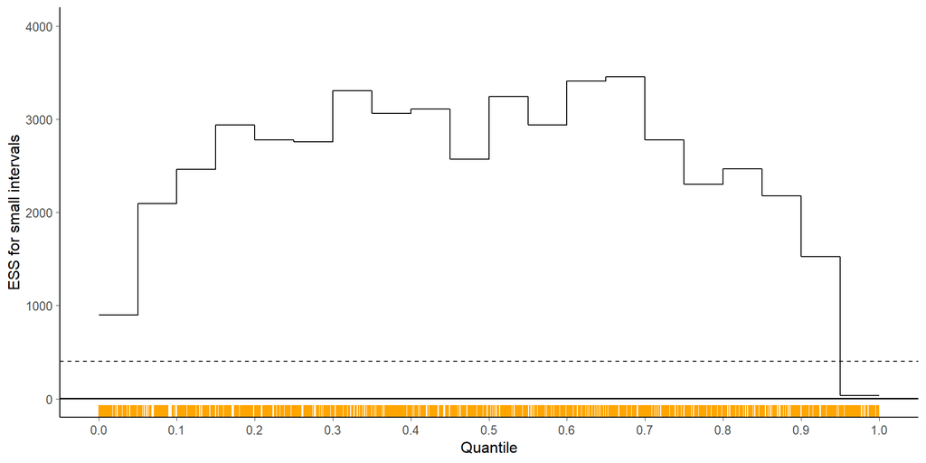

```r
plot_local_ess(fit = fit_nom, par = which_min_ess, nalpha = 20)
```

We see that the efficiency is worryingly low in the tails (which is caused by slow mixing in long tails of Cauchy). Orange ticks show draws that exceeded the maximum treedepth.

An alternative way to examine the effective sample size in different parts of the posterior is to compute effective sample size for quantiles (see Section Efficiency for quantiles). Each interval has a specified proportion of draws, and the efficiency measures mixing of an indicator function’s results which indicate when the values are inside the specific interval.

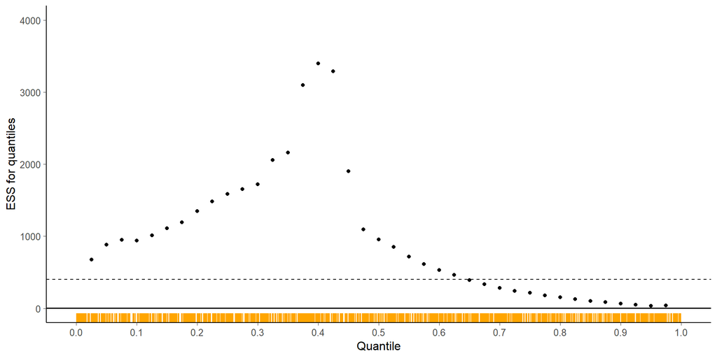

```r
plot_quantile_ess(fit = fit_nom, par = which_min_ess, nalpha = 40)
```

We see that the efficiency is worryingly low in the tails (which is caused by slow mixing in long tails of Cauchy). Orange ticks show draws that exceeded the maximum treedepth.

We can further analyze potential problems using rank plots, from which we clearly see differences between chains.

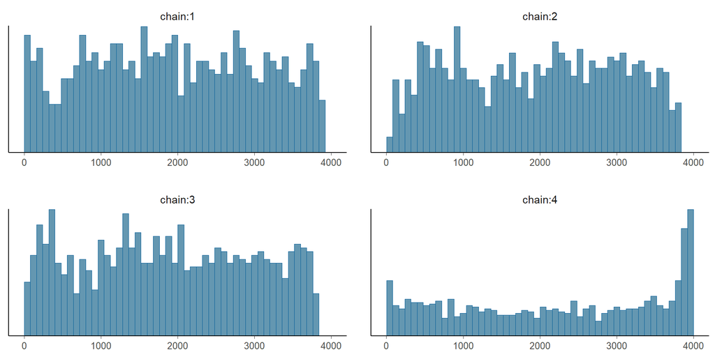

```r
xmin <- paste0("x[", which_min_ess, "]")
mcmc_hist_r_scale(samp[, , xmin])
```

#### 4.2.6.2 Default Stan options + increased maximum treedepth

We can try to improve the performance by increasing `max_treedepth` to $20$:

```r
fit_nom_td20 <- stan(
  file = 'cauchy_nom.stan', seed = 7878,
  refresh = 0, control = list(max_treedepth = 20)
)
```

Trace plots for the first parameter still look wild with occasional large values.

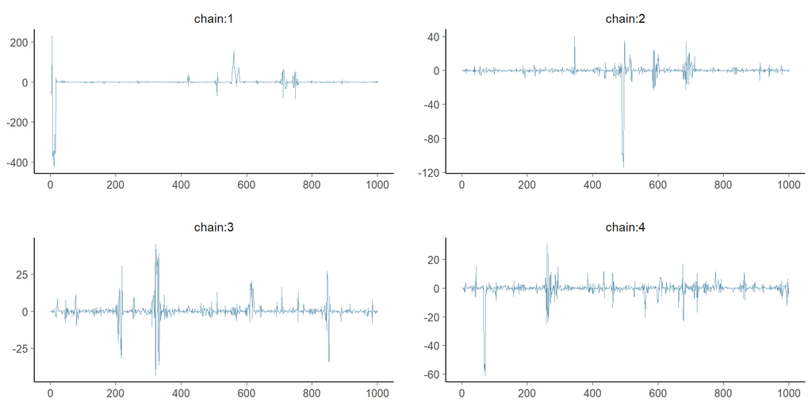

```r
samp <- as.array(fit_nom_td20)
mcmc_trace(samp[, , 1])
```

```r
res <- monitor_extra(samp[, , 1:50])
which_min_ess <- which.min(res$zsseff)
```

We check the diagnostics for all $x$.

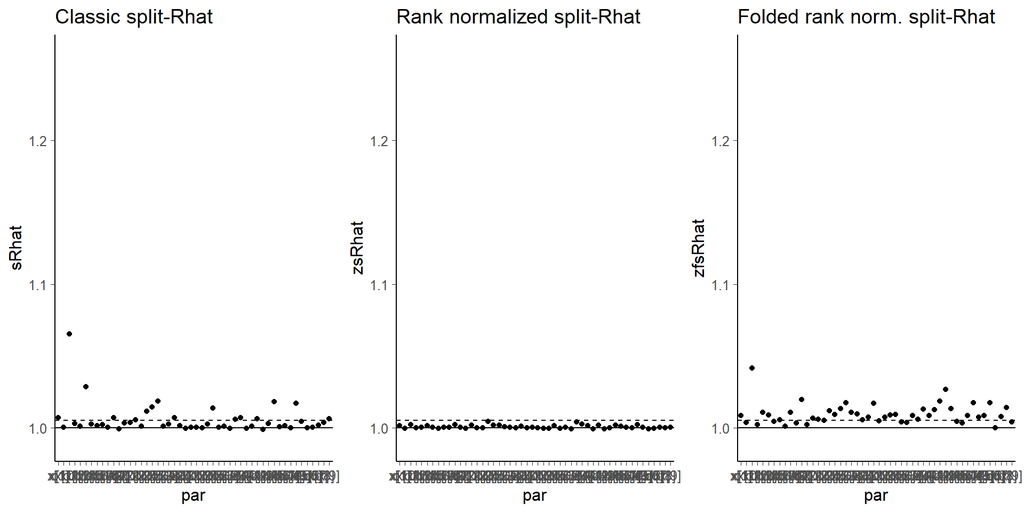

```r
plot_rhat(res)
```

All Rhats are below $1.1$, but many are over $1.01$. Classic split-Rhat has more variation than the rank normalized Rhat (note that the former is not well defined). The folded rank normalized Rhat shows that there is still more variation in the scale than in the location between different chains.

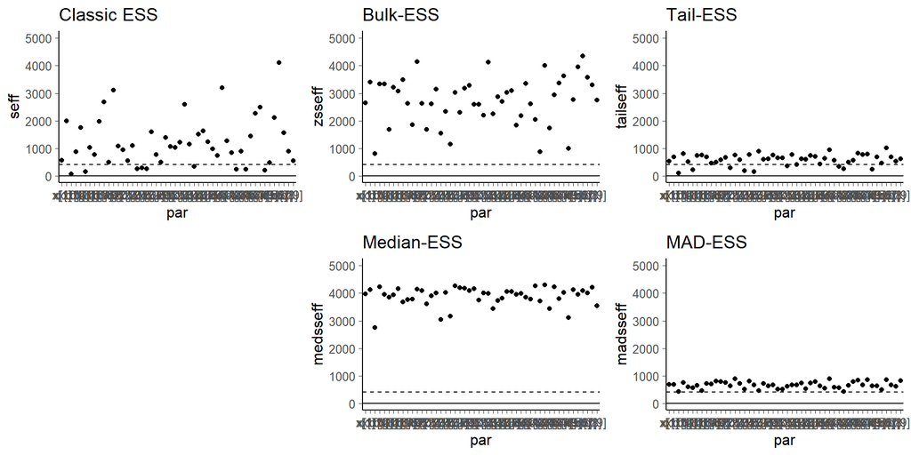

```r
plot_ess(res)
```

Some classic effective sample sizes are very small. If we wouldn’t realize that the variance is infinite, we might try to run longer chains, but in case of an infinite variance, zero relative efficiency (ESS/S) is the truth and longer chains won’t help with that. However other quantities can be well defined, and that’s why it is useful to also look at the rank normalized version as a generic transformation to achieve finite mean and variance. The smallest bulk-ESS is less than 1000, which is not that bad. The smallest median-ESS is larger than 2500, that is we are able to estimate the median efficiently. However, many tail-ESS’s are less than 400 indicating problems for estimating the scale of the posterior.

**Result:** The rank normalized effective sample size is more stable than classic effective sample size, which is not well defined for the Cauchy distribution.

**Result:** It is useful to look at both bulk- and tail-ESS.

We check also `lp__`. Although increasing `max_treedepth` improved bulk-ESS of `x`, the efficiency for `lp__` didn’t change.

```r
res <- monitor_extra(samp[, , 51:52])
cat('lp__: Bulk-ESS =', round(res['lp__', 'zsseff'], 2), '\n')
```

```
lp__: Bulk-ESS = 240
```

```r
cat('lp__: Tail-ESS =', round(res['lp__', 'tailseff'], 2), '\n')
```

```
lp__: Tail-ESS = 586.95
```

We examine the sampling efficiency in different parts of the posterior by computing the effective sample size for small interval probability estimates.

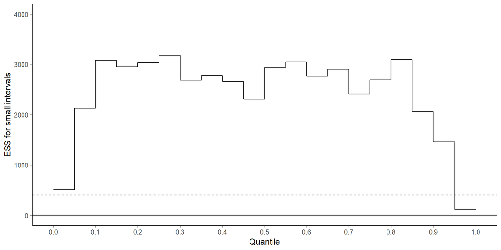

```r
plot_local_ess(fit = fit_nom_td20, par = which_min_ess, nalpha = 20)
```

It seems that increasing `max_treedepth` has not much improved the efficiency in the tails. We also examine the effective sample size of different quantile estimates.

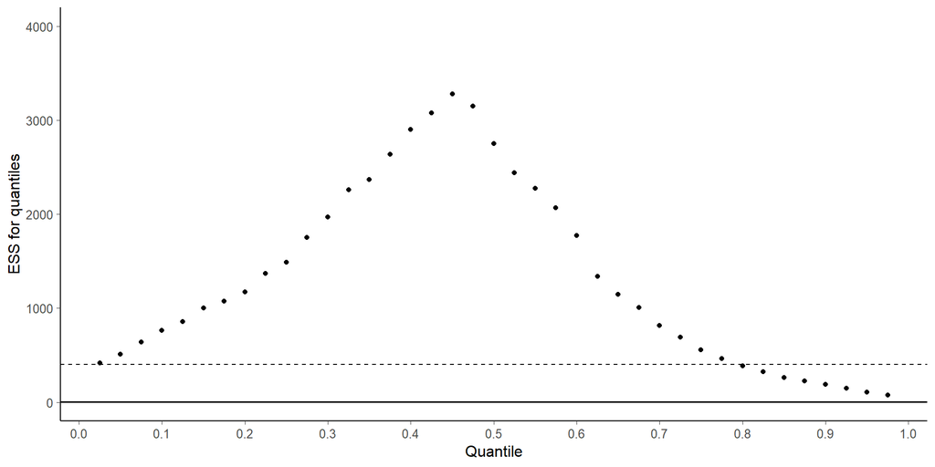

```r
plot_quantile_ess(fit = fit_nom_td20, par = which_min_ess, nalpha = 40)
```

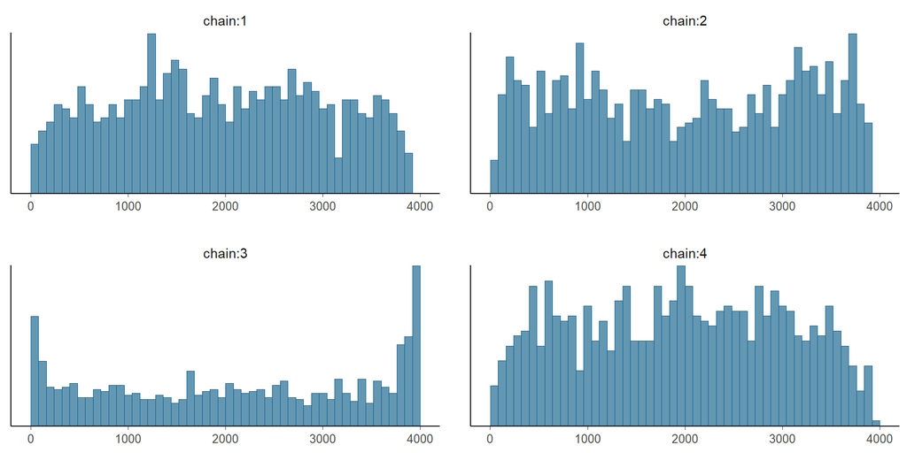

```r
xmin <- paste0("x[", which_min_ess, "]")
mcmc_hist_r_scale(samp[, , xmin])
```

The rank plot visualisation of `lp__`, which has an effective sample size 240, doesn’t look so good either.

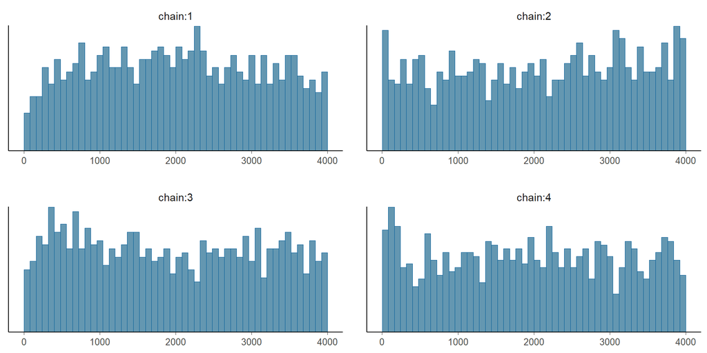

```r
mcmc_hist_r_scale(samp[, , "lp__"])
```

#### 4.2.6.3 Default Stan options + increased maximum treedepth + longer chains

Let’s try running 8 times longer chains.

```r
fit_nom_td20l <- stan(
  file = 'cauchy_nom.stan', seed = 7878,
  refresh = 0, control = list(max_treedepth = 20),
  warmup = 1000, iter = 9000
)
```

Trace plots for the first parameter still look wild with occasional large values.

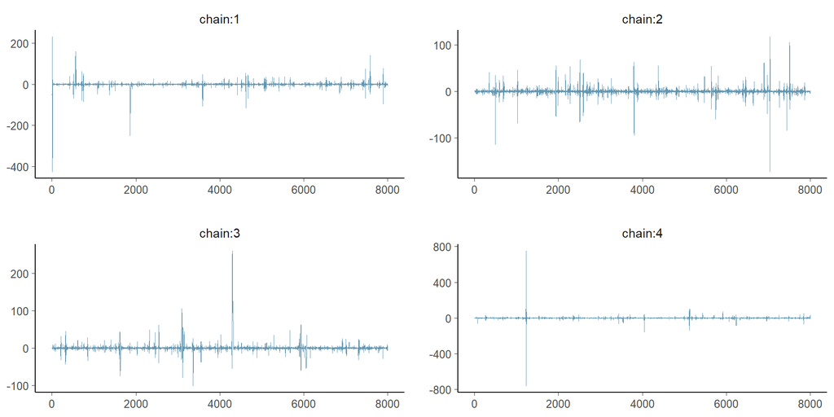

```r
samp <- as.array(fit_nom_td20l)
mcmc_trace(samp[, , 1])
```

```r
res <- monitor_extra(samp[, , 1:50])
which_min_ess <- which.min(res$zsseff)
```

Let’s check the diagnostics for all $x$.

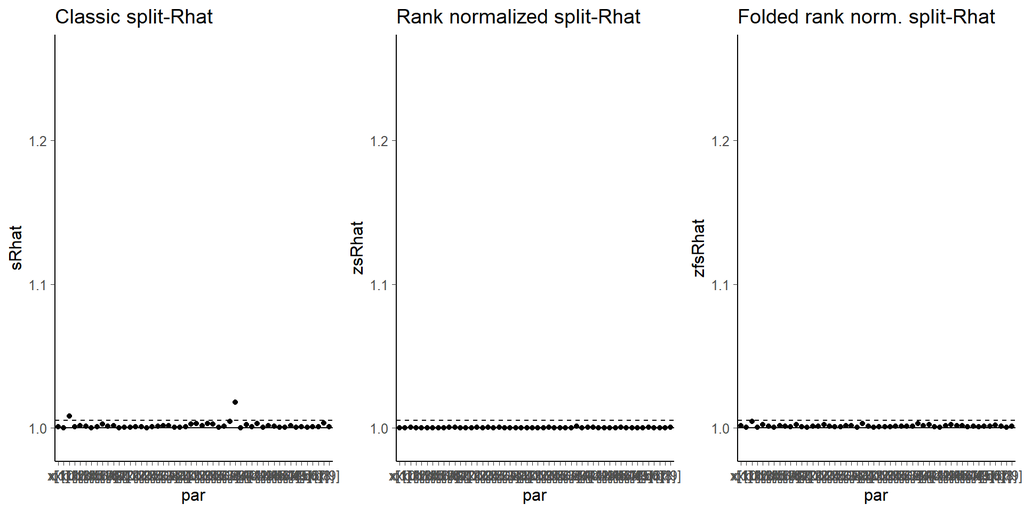

```r
plot_rhat(res)
```

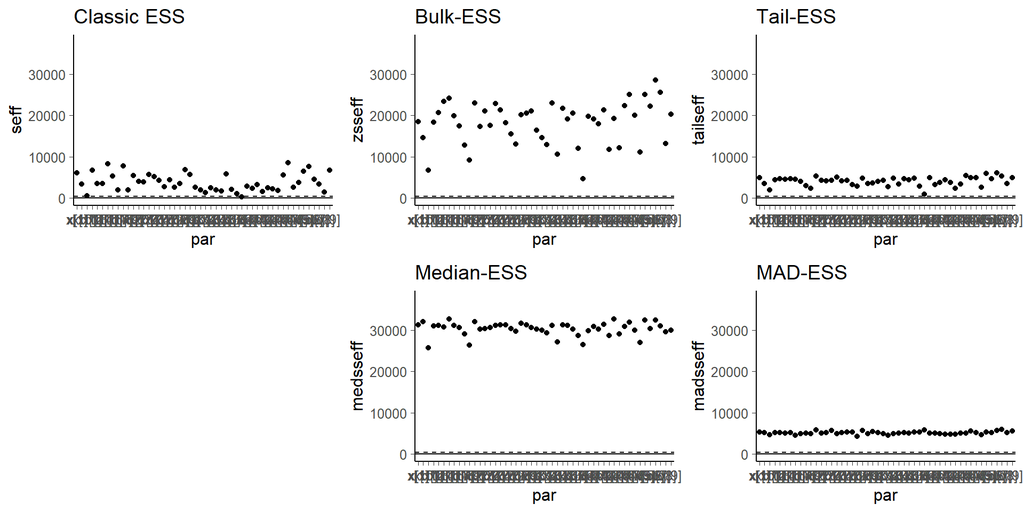

```r
plot_ess(res)
```

The smallest bulk-ESS are around 5000, which is not that bad. The smallest median-ESS’s are larger than 25000, that is we are able to estimate the median efficiently. However, the smallest tail-ESS is 919.37 indicating problems for estimating the scale of the posterior.

**Result:** The rank normalized effective sample size is more stable than classic effective sample size even for very long chains.

**Result:** It is useful to look at both bulk- and tail-ESS.

We also check `lp__`. Although increasing the number of iterations improved bulk-ESS of the $x$, the relative efficiency for `lp__` didn’t change.

```r
res <- monitor_extra(samp[, , 51:52])
cat('lp__: Bulk-ESS =', round(res['lp__', 'zsseff'], 2), '\n')
```

```
lp__: Bulk-ESS = 1289
```

```r
cat('lp__: Tail-ESS =', round(res['lp__', 'tailseff'], 2), '\n')
```

```
lp__: Tail-ESS = 1886.54
```

We examine the sampling efficiency in different parts of the posterior by computing the effective sample size for small interval probability estimates.

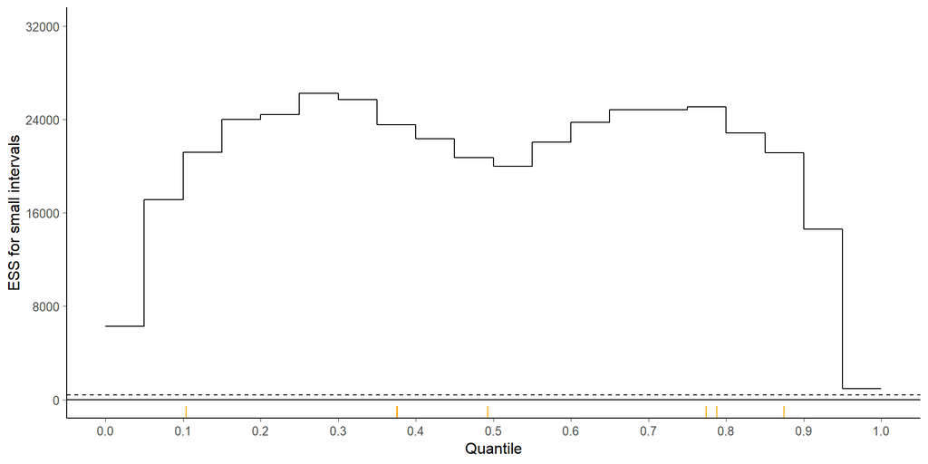

```r
plot_local_ess(fit = fit_nom_td20l, par = which_min_ess, nalpha = 20)
```

Increasing the chain length did not seem to change the relative efficiency. With more draws from the longer chains we can use a finer resolution for the local efficiency estimates.

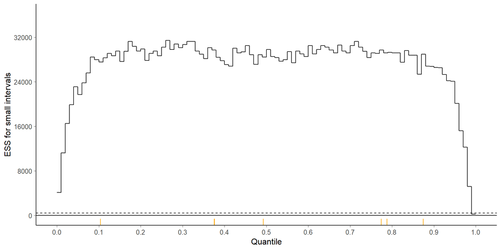

```r
plot_local_ess(fit = fit_nom_td20l, par = which_min_ess, nalpha = 100)
```

The sampling efficiency far in the tails is worryingly low. This was more difficult to see previously with less draws from the tails. We see similar problems in the plot of effective sample size for quantiles.

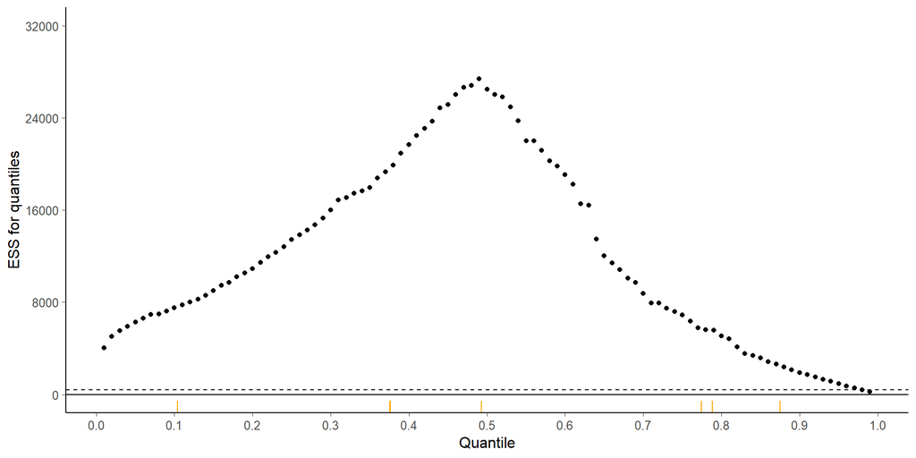

```r
plot_quantile_ess(fit = fit_nom_td20l, par = which_min_ess, nalpha = 100)
```

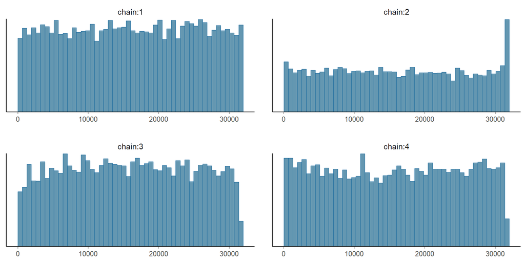

```r
xmin <- paste0("x[", which_min_ess, "]")
mcmc_hist_r_scale(samp[, , xmin])
```

Increasing the number of iterations couldn’t remove the mixing problems at the tails. The mixing problem is inherent to the nominal parameterization of Cauchy distribution.

### 4.2.7 First alternative parameterization of the Cauchy distribution

Next, we examine an alternative parameterization and consider the Cauchy distribution as a scale mixture of Gaussian distributions. The model has two parameters and the Cauchy distributed $x$ can be computed from those. In addition to improved sampling performance, the example illustrates that focusing on diagnostics matters.

```r
writeLines(readLines("cauchy_alt_1.stan"))
```

```
parameters {
  vector[50] x_a;
  vector<lower=0>[50] x_b;
}

transformed parameters {
  vector[50] x = x_a ./ sqrt(x_b);
}

model {
  x_a ~ normal(0, 1);
  x_b ~ gamma(0.5, 0.5);
}

generated quantities {
  real I = fabs(x[1]) < 1 ? 1 : 0;
}
```

We run the alternative model:

```r
fit_alt1 <- stan(file='cauchy_alt_1.stan', seed=7878, refresh = 0)
```

There are no warnings and the sampling is much faster.

```r
samp <- as.array(fit_alt1)
res <- monitor_extra(samp[, , 101:150])
which_min_ess <- which(res$zsseff == min(res$zsseff))
```

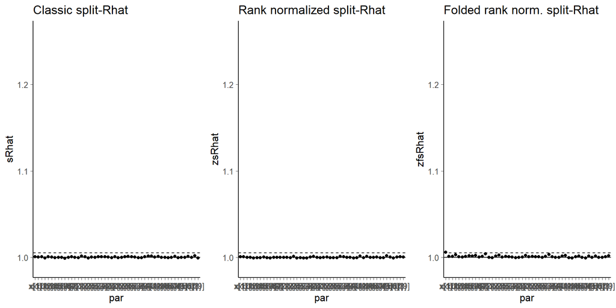

```r
plot_rhat(res)
```

All Rhats are below $1.01$. Classic split-Rhats also look good even though they are not well defined for the Cauchy distribution.

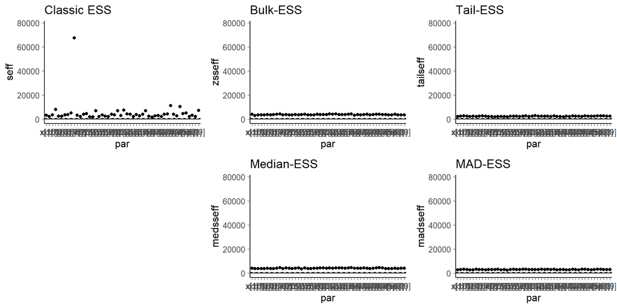

```r
plot_ess(res)
```

**Result:** Rank normalized ESS’s have less variation than classic one which is not well defined for Cauchy.

We check `lp__`:

```r
res <- monitor_extra(samp[, , 151:152])
cat('lp__: Bulk-ESS =', round(res['lp__', 'zsseff'], 2), '\n')
```

```
lp__: Bulk-ESS = 1310
```

```r
cat('lp__: Tail-ESS =', round(res['lp__', 'tailseff'], 2), '\n')
```

```
lp__: Tail-ESS = 1927.69
```

The relative efficiencies for `lp__` are also much better than with the nominal parameterization.

We examine the sampling efficiency in different parts of the posterior by computing the effective sample size for small interval probability estimates.

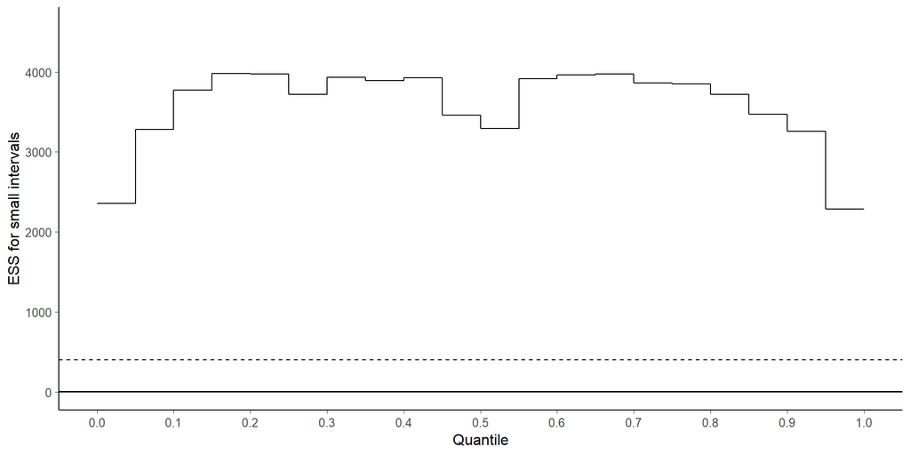

```r
plot_local_ess(fit = fit_alt1, par = 100 + which_min_ess, nalpha = 20)
```

The effective sample size is good in all parts of the posterior. We also examine the effective sample size of different quantile estimates.

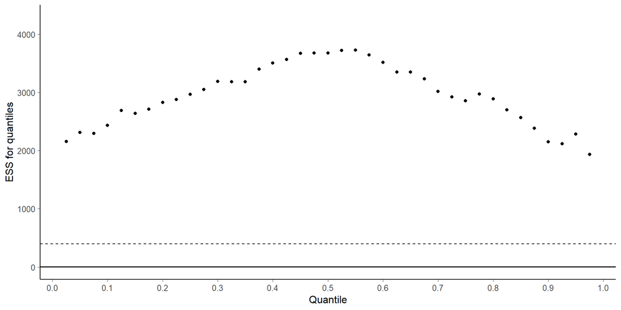

```r
plot_quantile_ess(fit = fit_alt1, par = 100 + which_min_ess, nalpha = 40)
```

We compare the mean relative efficiencies of the underlying parameters in the new parameterization and the actual $x$ we are interested in.

```r
res <- monitor_extra(samp[, , 101:150])
res1 <- monitor_extra(samp[, , 1:50])
res2 <- monitor_extra(samp[, , 51:100])
```

```r
cat('Mean Bulk-ESS for x =' , round(mean(res[, 'zsseff']), 2), '\n')
```

```
Mean Bulk-ESS for x = 3629.24
```

```r
cat('Mean Tail-ESS for x =' , round(mean(res[, 'tailseff']), 2), '\n')
```

```
Mean Tail-ESS for x = 2265.23
```

```r
cat('Mean Bulk-ESS for x_a =' , round(mean(res1[, 'zsseff']), 2), '\n')
```

```
Mean Bulk-ESS for x_a = 3956.06
```

```r
cat('Mean Bulk-ESS for x_b =' , round(mean(res2[, 'zsseff']), 2), '\n')
```

```
Mean Bulk-ESS for x_b = 2761.22
```

**Result:** We see that the effective sample size of the interesting $x$ can be different from the effective sample size of the parameters $x_a$ and $x_b$ that we used to compute it.

The rank plot visualisation of x[10], which has the smallest effective sample size of 2871 among the $x$ looks better than for the nominal parameterization.

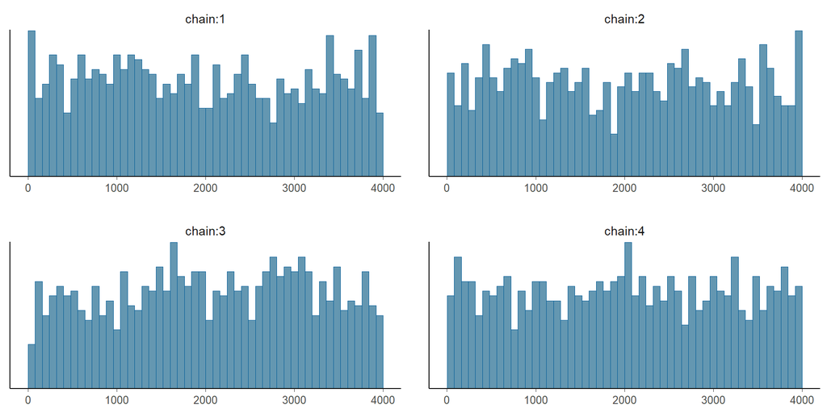

```r
xmin <- paste0("x[", which_min_ess, "]")
mcmc_hist_r_scale(samp[, , xmin])
```

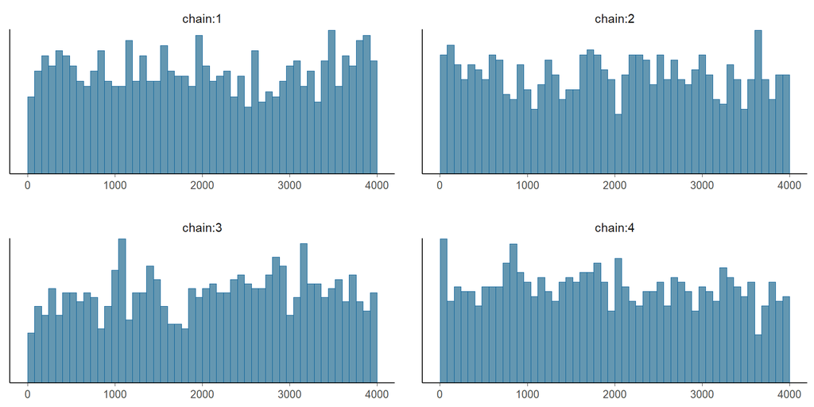

```r
mcmc_hist_r_scale(samp[, , "lp__"])
```

### 4.2.8 Another alternative parameterization of the Cauchy distribution

Another alternative parameterization is obtained by a univariate transformation as shown in the following code (see also the 3rd alternative in Michael Betancourt’s case study).

```r
writeLines(readLines("cauchy_alt_3.stan"))
```

```
parameters {
  vector<lower=0, upper=1>[50] x_tilde;
}

transformed parameters {
vector[50] x = tan(pi() * (x_tilde - 0.5));
}

model {
  // Implicit uniform prior on x_tilde
}

generated quantities {
  real I = fabs(x[1]) < 1 ? 1 : 0;
}
```

We run the alternative model:

```r
fit_alt3 <- stan(file='cauchy_alt_3.stan', seed=7878, refresh = 0)
```

There are no warnings, and the sampling is much faster than for the nominal model.

```r
samp <- as.array(fit_alt3)
res <- monitor_extra(samp[, , 51:100])
which_min_ess <- which(res$zsseff == min(res$zsseff))
```

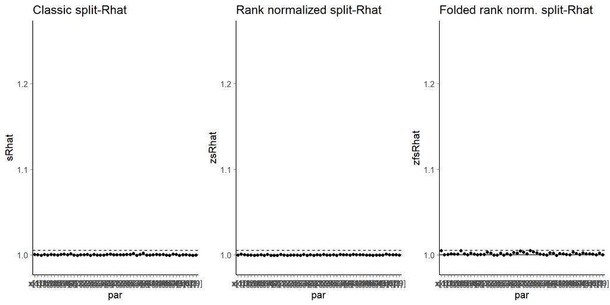

```r
plot_rhat(res)
```

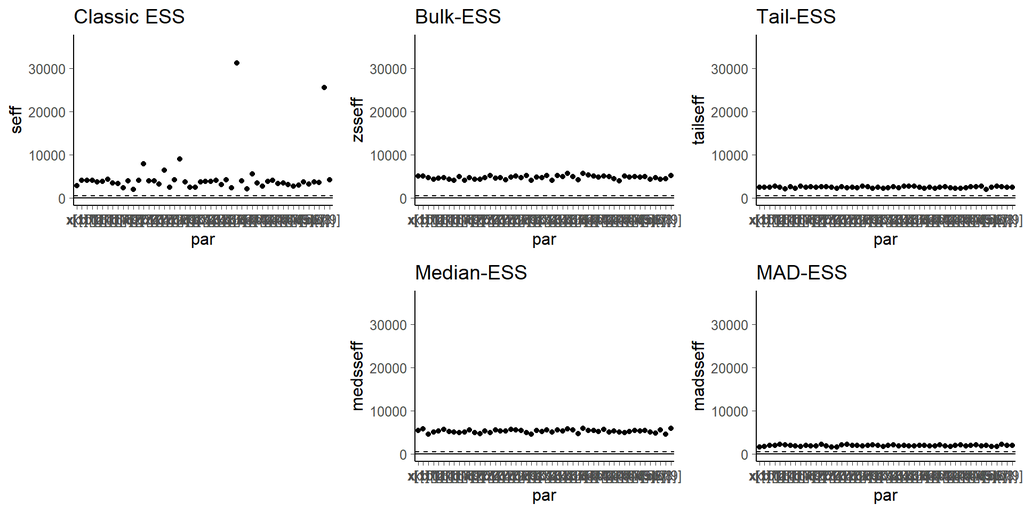

```r
plot_ess(res)
```

**Result:** Rank normalized relative efficiencies have less variation than classic ones. Bulk-ESS and median-ESS are slightly larger than 1, which is possible for antithetic Markov chains which have negative correlation for odd lags.

We also take a closer look at the `lp__` value:

```r
res <- monitor_extra(samp[, , 101:102])
cat('lp__: Bulk-ESS =', round(res['lp__', 'zsseff'], 2), '\n')
```

```
lp__: Bulk-ESS = 1494
```

```r
cat('lp__: Tail-ESS =', round(res['lp__', 'tailseff'], 2), '\n')
```

```
lp__: Tail-ESS = 1883.75
```

The effective sample size for these are also much better than with the nominal parameterization.

We examine the sampling efficiency in different parts of the posterior by computing the effective sample size for small interval probability estimates.

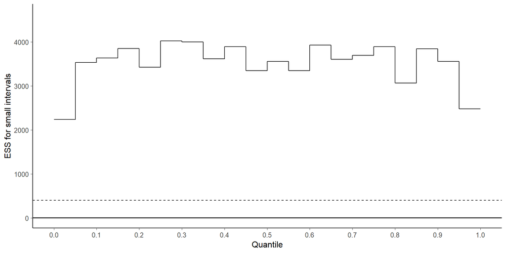

```r
plot_local_ess(fit = fit_alt3, par = 50 + which_min_ess, nalpha = 20)
```

We examine also the sampling efficiency of different quantile estimates.

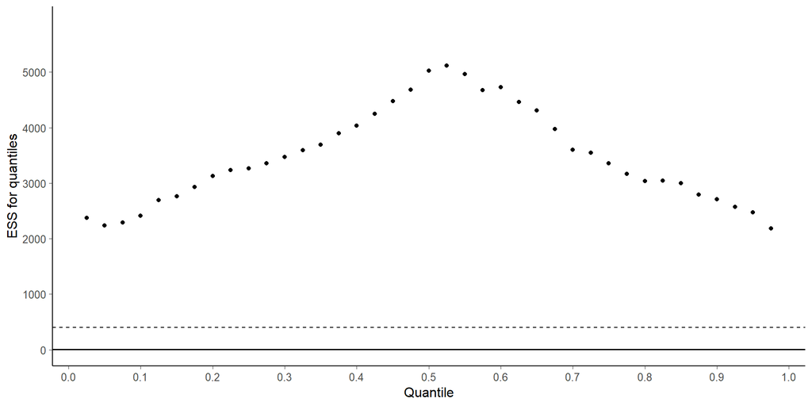

```r
plot_quantile_ess(fit = fit_alt3, par = 50 + which_min_ess, nalpha = 40)
```

The effective sample size in tails is worse than for the first alternative parameterization, although it’s still better than for the nominal parameterization.

We compare the mean effective sample size of the underlying parameter in the new parameterization and the actually Cauchy distributed $x$ we are interested in.

```r
res <- monitor_extra(samp[, , 51:100])
res1 <- monitor_extra(samp[, , 1:50])
cat('Mean bulk-seff for x =' , round(mean(res[, 'zsseff']), 2), '\n')
```

```
Mean bulk-seff for x = 4702.98
```

```r
cat('Mean tail-seff for x =' , round(mean(res[, 'zfsseff']), 2), '\n')
```

```
Mean tail-seff for x = 1602.7
```

```r
cat('Mean bulk-seff for x_tilde =' , round(mean(res1[, 'zsseff']), 2), '\n')
```

```
Mean bulk-seff for x_tilde = 4702.98
```

```r
cat('Mean tail-seff for x_tilde =' , round(mean(res1[, 'zfsseff']), 2), '\n')
```

```
Mean tail-seff for x_tilde = 1612.14
```

The Rank plot visualisation of x[45], which has the smallest effective sample size of 3957 among the $x$ reveals shows good efficiency, similar to the results for `lp__`.

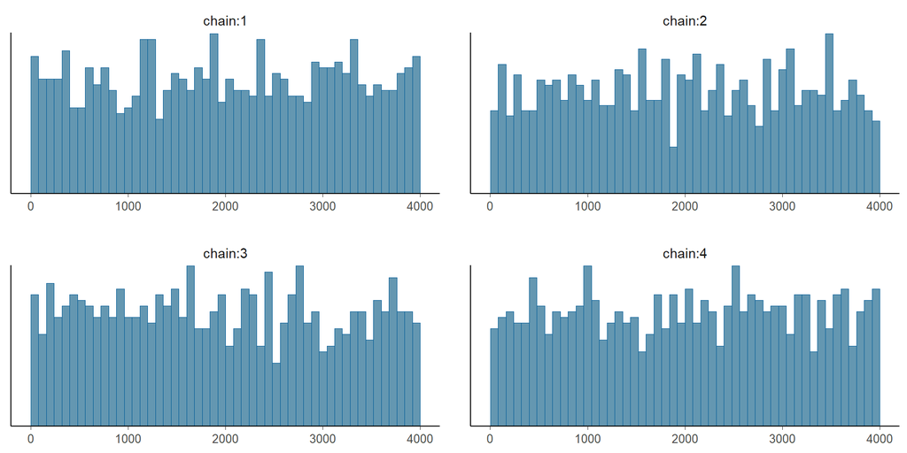

```r
xmin <- paste0("x[", which_min_ess, "]")
mcmc_hist_r_scale(samp[, , xmin])
```

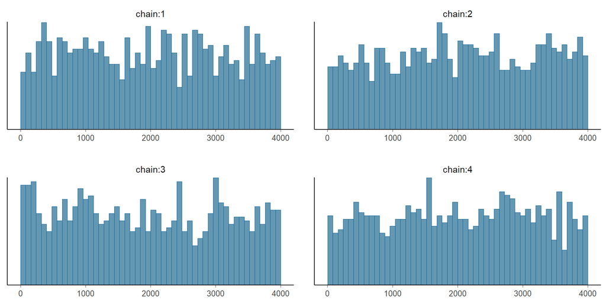

```r
mcmc_hist_r_scale(samp[, , "lp__"])
```

### 4.2.9 Half-Cauchy distribution with nominal parameterization

Half-Cauchy priors are common and, for example, in Stan usually set using the nominal parameterization. However, when the constraint `<lower=0>` is used, Stan does the sampling automatically in the unconstrained `log(x)` space, which changes the geometry crucially.

```r
writeLines(readLines("half_cauchy_nom.stan"))
```

```
parameters {
  vector<lower=0>[50] x;
}

model {
  x ~ cauchy(0, 1);
}

generated quantities {
  real I = fabs(x[1]) < 1 ? 1 : 0;
}
```

We run the half-Cauchy model with nominal parameterization (and positive constraint).

```r
fit_half_nom <- stan(file = 'half_cauchy_nom.stan', seed = 7878, refresh = 0)
```

There are no warnings and the sampling is much faster than for the full Cauchy distribution with nominal parameterization.

```r
samp <- as.array(fit_half_nom)
res <- monitor_extra(samp[, , 1:50])
which_min_ess <- which.min(res$zsseff)
```

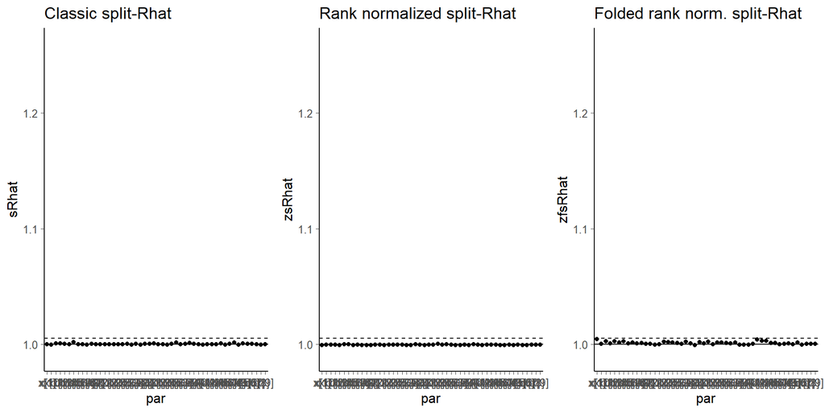

```r
plot_rhat(res)
```

All Rhats are below $1.01$. Classic split-Rhats also look good even though they are not well defined for the half-Cauchy distribution.

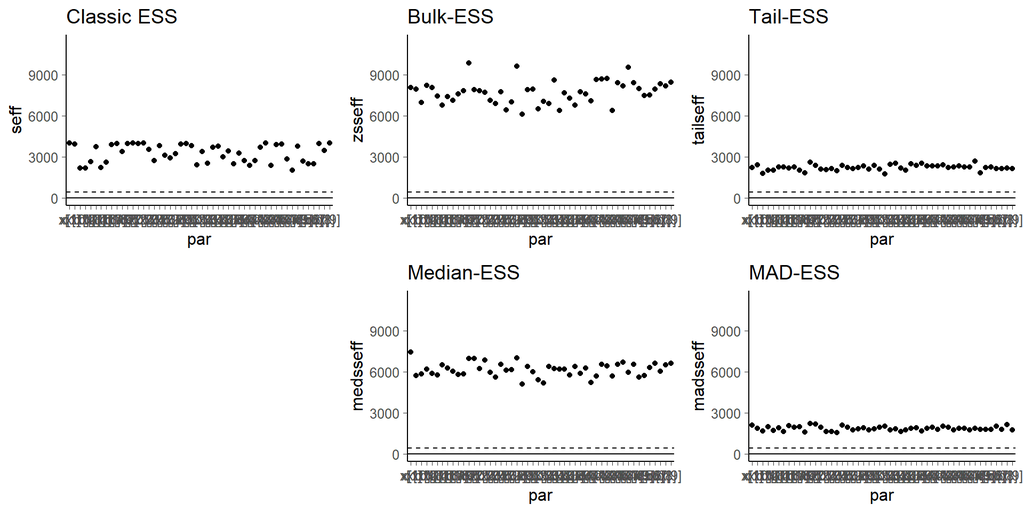

```r
plot_ess(res)
```

Due to the `<lower=0>` constraint, the sampling was made in the `log(x)` space, and we can also check the performance in that space.

```r
res <- monitor_extra(log(samp[, , 1:50]))
```

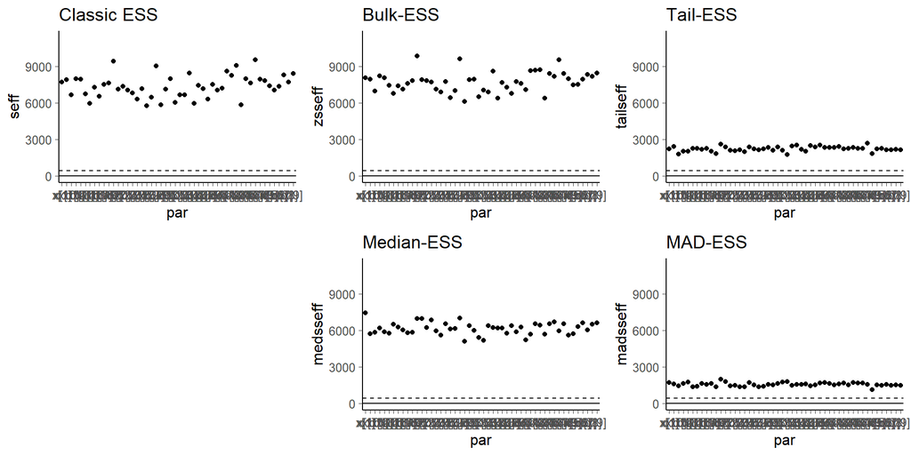

```r
plot_ess(res)
```

$\log(x)$ is quite close to Gaussian, and thus classic effective sample size is also close to rank normalized ESS which is exactly the same as for the original $x$ as rank normalization is invariant to bijective transformations.

**Result:** The rank normalized effective sample size is close to the classic effective sample size for transformations which make the distribution close to Gaussian.

We examine the sampling efficiency in different parts of the posterior by computing the effective sample size for small interval probability estimates.

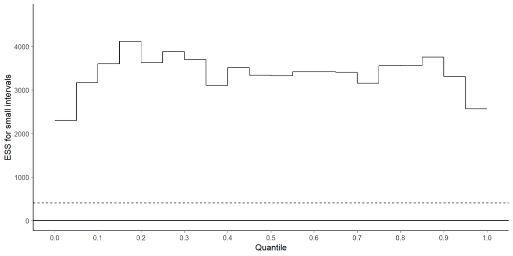

```r
plot_local_ess(fit = fit_half_nom, par = which_min_ess, nalpha = 20)
```

The effective sample size is good overall, with only a small dip in tails. We can also examine the effective sample size of different quantile estimates.

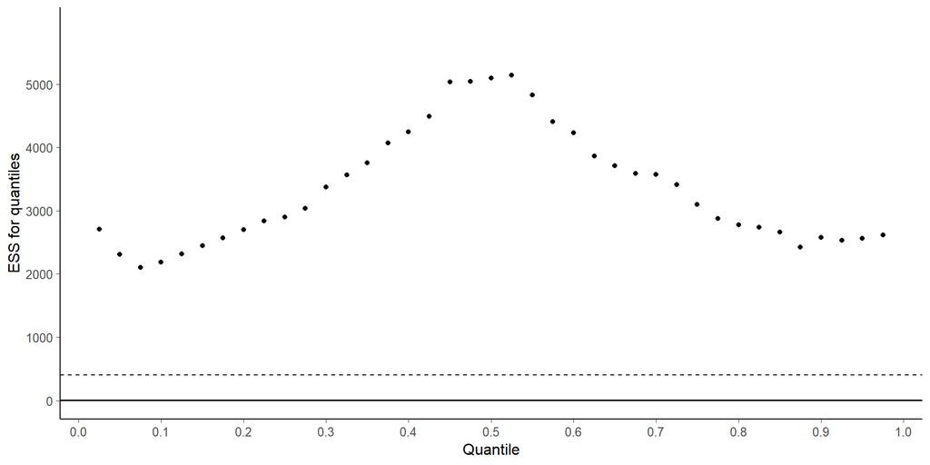

```r
plot_quantile_ess(fit = fit_half_nom, par = which_min_ess, nalpha = 40)
```

The rank plot visualisation of x[29], which has the smallest effective sample size of 6109 among $x$, looks good.

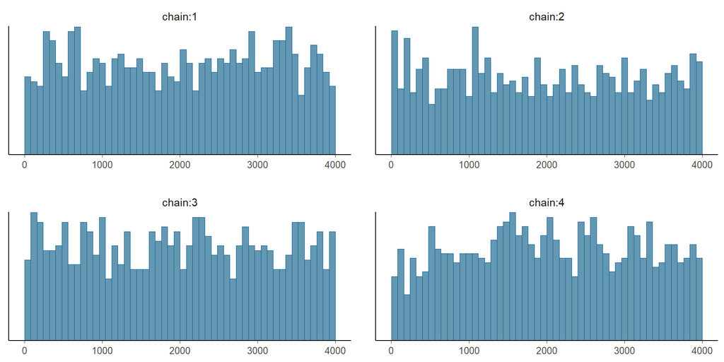

```r
xmin <- paste0("x[", which_min_ess, "]")
mcmc_hist_r_scale(samp[, , xmin])
```

The rank plot visualisation of `lp__` reveals some small differences in the scales, but it’s difficult to know whether this small variation from uniform is relevant.

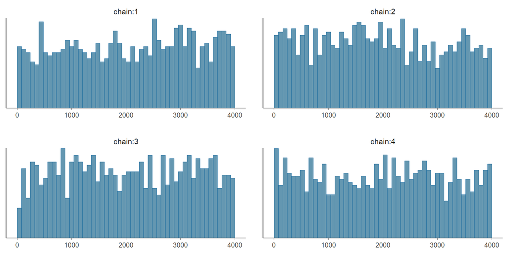

```r
mcmc_hist_r_scale(samp[, , "lp__"])
```

### 4.2.10 Alternative parameterization of the half-Cauchy distribution

```r
writeLines(readLines("half_cauchy_alt.stan"))
```

```
parameters {
  vector<lower=0>[50] x_a;
  vector<lower=0>[50] x_b;
}

transformed parameters {
  vector[50] x = x_a .* sqrt(x_b);
}

model {
  x_a ~ normal(0, 1);
  x_b ~ inv_gamma(0.5, 0.5);
}

generated quantities {
  real I = fabs(x[1]) < 1 ? 1 : 0;
}
```

Run half-Cauchy with alternative parameterization

```r
fit_half_reparam <- stan(
  file = 'half_cauchy_alt.stan', seed = 7878, refresh = 0
)
```

There are no warnings and the sampling is as fast for the half-Cauchy nominal model.

```r
samp <- as.array(fit_half_reparam)
res <- monitor_extra(samp[, , 101:150])
which_min_ess <- which.min(res$zsseff)
```

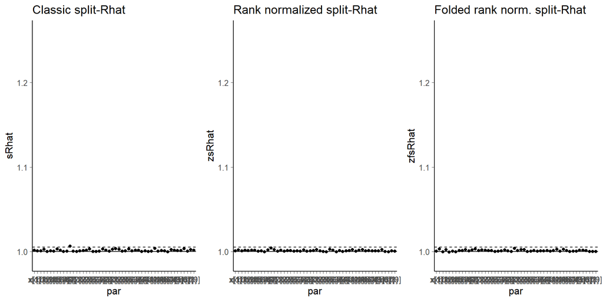

```r
plot_rhat(res)
```

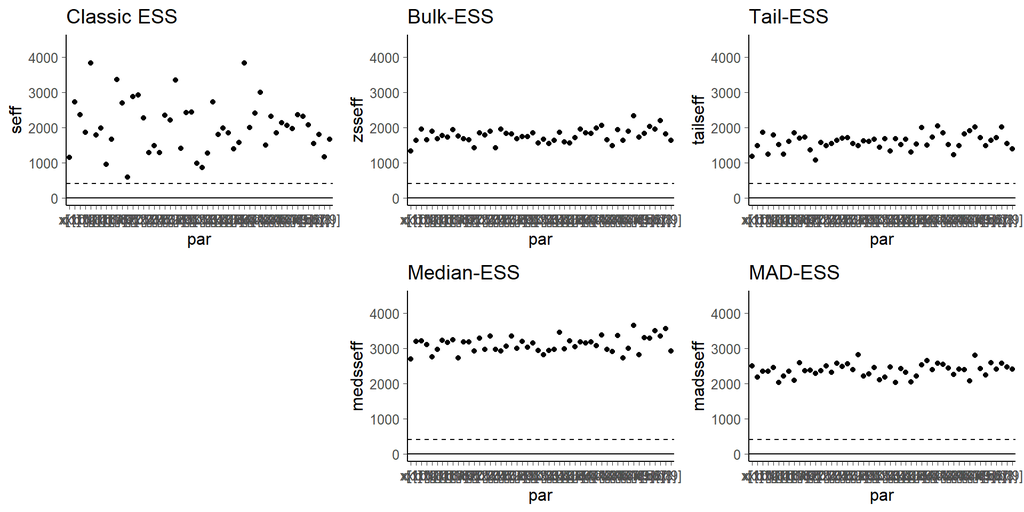

```r
plot_ess(res)
```

**Result:** The Rank normalized relative efficiencies have less variation than classic ones which is not well defined for the Cauchy distribution. Based on bulk-ESS and median-ESS, the efficiency for central quantities is much lower, but based on tail-ESS and MAD-ESS, the efficiency in the tails is slightly better than for the half-Cauchy distribution with nominal parameterization. We also see that a parameterization which is good for the full Cauchy distribution is not necessarily good for the half-Cauchy distribution as the `<lower=0>` constraint additionally changes the parameterization.

We also check the `lp__` values:

```r
res <- monitor_extra(samp[, , 151:152])
cat('lp__: Bulk-ESS =', round(res['lp__', 'zsseff'], 2), '\n')
```

```
lp__: Bulk-ESS = 977
```

```r
cat('lp__: Tail-ESS =', round(res['lp__', 'tailseff'], 2), '\n')
```

```
lp__: Tail-ESS = 1750.46
```

We examine the sampling efficiency in different parts of the posterior by computing the effective sample size for small interval probability estimates.

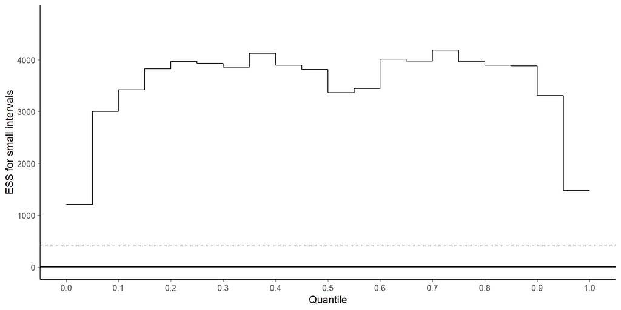

```r
plot_local_ess(fit_half_reparam, par = 100 + which_min_ess, nalpha = 20)
```

We also examine the effective sample size for different quantile estimates.

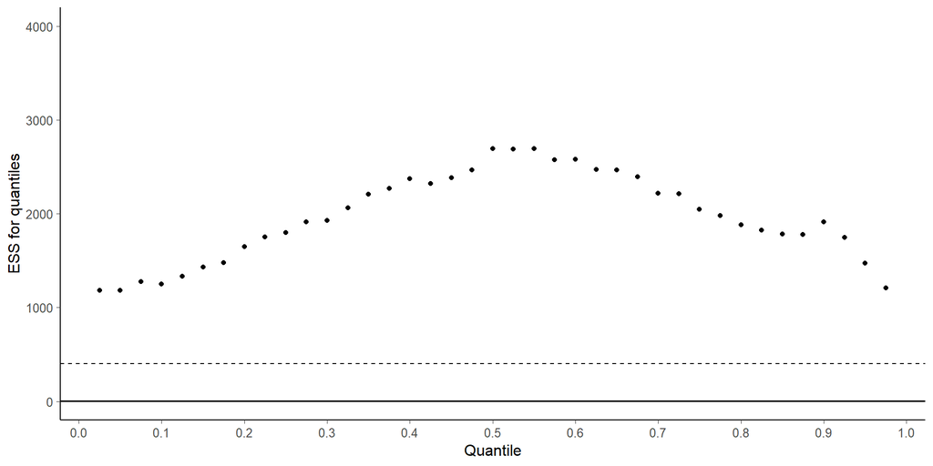

```r
plot_quantile_ess(fit_half_reparam, par = 100 + which_min_ess, nalpha = 40)
```

The effective sample size near zero is much worse than for the half-Cauchy distribution with nominal parameterization.

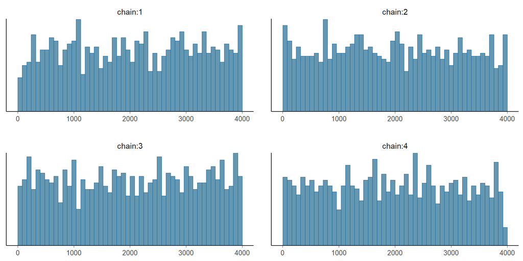

```r
xmin <- paste0("x[", which_min_ess, "]")
mcmc_hist_r_scale(samp[, , xmin])
```

A similar result is obtained when looking at the rank plots of `lp__`.

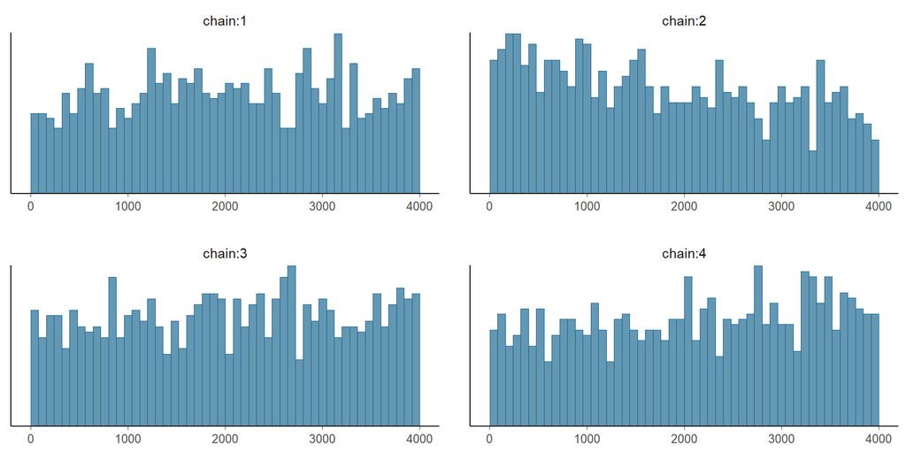

```r
mcmc_hist_r_scale(samp[, , "lp__"])
```

## Appendix F: Hierarchical model: Eight Schools

We continue with our discussion about hierarchical models on the Eight Schools data, which we started in Section Eight Schools. We also analyse the performance of different variants of the diagnostics.

### 4.2.11 A Centered Eight Schools model

```r
writeLines(readLines("eight_schools_cp.stan"))
```

```
data {
  int<lower=0> J;
  real y[J];
  real<lower=0> sigma[J];
}

parameters {
  real mu;
  real<lower=0> tau;
  real theta[J];
}

model {
  mu ~ normal(0, 5);
  tau ~ cauchy(0, 5);
  theta ~ normal(mu, tau);
  y ~ normal(theta, sigma);
}
```

In the main text, we observed that the centered parameterization of this hierarchical model did not work well with the default MCMC options of Stan plus increased `adapt_delta`, and so we directly try to fit the model with longer chains.

#### 4.2.11.1 Centered parameterization with longer chains

Low efficiency can be sometimes compensated with longer chains. Let’s check 10 times longer chain.

```r
fit_cp2 <- stan(
  file = 'eight_schools_cp.stan', data = eight_schools,
  iter = 20000, chains = 4, seed = 483892929, refresh = 0,
  control = list(adapt_delta = 0.95)
)
monitor(fit_cp2)
```

```
Inference for the input samples (4 chains: each with iter = 20000; warmup = 10000):

             Q5    Q50   Q95   Mean   SD Rhat Bulk_ESS Tail_ESS
mu        -0.99   4.84 10.34   4.88 3.57 1.05       71      189
tau        0.33   2.81 10.02   3.67 3.31 1.08       45       17
theta[1]  -1.36   6.43 16.32   6.76 5.64 1.01      407     9491
theta[2]  -2.48   5.47 12.55   5.42 4.80 1.02      153     9429
theta[3]  -4.92   4.66 11.52   4.41 5.43 1.03      117    10374
theta[4]  -2.89   5.34 12.40   5.23 4.97 1.03      140     9670
theta[5]  -4.48   4.32 10.69   4.09 4.94 1.04       89     4758
theta[6]  -4.15   4.70 11.27   4.49 5.08 1.03      118    11277
theta[7]  -0.88   6.60 15.53   6.83 5.11 1.01      449    11102
theta[8]  -3.46   5.41 13.34   5.34 5.49 1.02      172    10408
lp__     -24.94 -14.78  0.22 -13.84 7.59 1.07       50       86

For each parameter, Bulk_ESS and Tail_ESS are crude measures of
effective sample size for bulk and tail quantities respectively (good values is
ESS > 400), and Rhat is the potential scale reduction factor on rank normalized
split chains (at convergence, Rhat = 1).
```

```r
res <- monitor_extra(fit_cp2)
print(res)
```

```
Inference for the input samples (4 chains: each with iter = 20000; warmup = 10000):

           mean se_mean   sd     Q5    Q50   Q95 seff reff sseff zseff zsseff zsreff Rhat sRhat
mu         4.88    0.49 3.57  -0.99   4.84 10.34   53 0.00    71    54     71   0.00 1.05  1.05
tau        3.67    0.30 3.31   0.33   2.81 10.02  123 0.00   173    35     45   0.00 1.02  1.02
theta[1]   6.76    0.22 5.64  -1.36   6.43 16.32  666 0.02  1057   281    407   0.01 1.01  1.01
theta[2]   5.42    0.43 4.80  -2.48   5.47 12.55  124 0.00   169   113    153   0.00 1.02  1.02
theta[3]   4.41    0.53 5.43  -4.92   4.66 11.52  105 0.00   146    86    117   0.00 1.03  1.02
theta[4]   5.23    0.46 4.97  -2.89   5.34 12.40  118 0.00   163   105    140   0.00 1.02  1.02
theta[5]   4.09    0.57 4.94  -4.48   4.32 10.69   76 0.00   102    69     89   0.00 1.03  1.03
theta[6]   4.49    0.51 5.08  -4.15   4.70 11.27  100 0.00   137    87    118   0.00 1.03  1.03
theta[7]   6.83    0.23 5.11  -0.88   6.60 15.53  512 0.01   745   309    449   0.01 1.01  1.01
theta[8]   5.34    0.43 5.49  -3.46   5.41 13.34  162 0.00   231   125    172   0.00 1.02  1.02
lp__     -13.84    1.32 7.59 -24.94 -14.78  0.22   33 0.00    44    37     50   0.00 1.08  1.08
         zRhat zsRhat zfsRhat zfsseff zfsreff tailseff tailreff medsseff medsreff madsseff madsreff
mu        1.05   1.05    1.02     152    0.00      189     0.00      174        0      174     0.00
tau       1.08   1.08    1.01    1035    0.03       17     0.00      175        0      167     0.00
theta[1]  1.01   1.01    1.00    3297    0.08     9491     0.24      177        0      268     0.01
theta[2]  1.02   1.02    1.00    1817    0.05     9429     0.24      173        0      177     0.00
theta[3]  1.03   1.03    1.01     736    0.02    10374     0.26      168        0      172     0.00
theta[4]  1.03   1.03    1.01    1468    0.04     9670     0.24      167        0      167     0.00
theta[5]  1.04   1.04    1.01     375    0.01     4758     0.12      170        0      178     0.00
theta[6]  1.03   1.03    1.01     644    0.02    11277     0.28      176        0      176     0.00
theta[7]  1.01   1.01    1.00    2761    0.07    11102     0.28      179        0      852     0.02
theta[8]  1.02   1.02    1.00    2816    0.07    10408     0.26      166        0      191     0.00
lp__      1.07   1.07    1.06      55    0.00       86     0.00      170        0      157     0.00
```

We still get a whole bunch of divergent transitions so it’s clear that the results can’t be trusted even if all other diagnostics were good. Still, it may be worth looking at additional diagnostics to better understand what’s happening.

We examine the sampling efficiency in different parts of the posterior by computing the effective sample size for small intervals for `tau`.

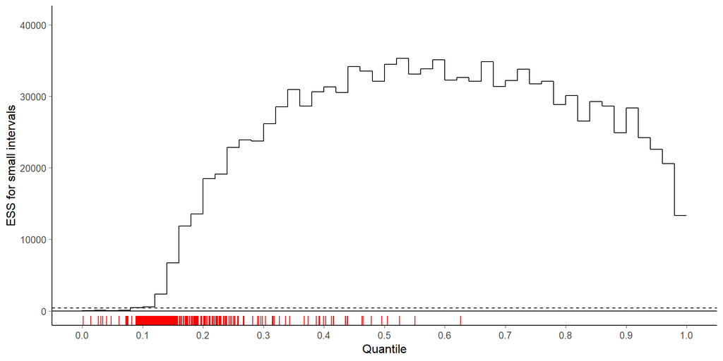

```r
plot_local_ess(fit = fit_cp2, par = "tau", nalpha = 50)
```

We see that the sampling has difficulties in exploring small `tau` values. As ESS<400 for small probability intervals in case of small `tau` values, we may suspect that we may miss substantial amount of posterior mass and get biased estimates.

We also examine the effective sample size of different quantile estimates.

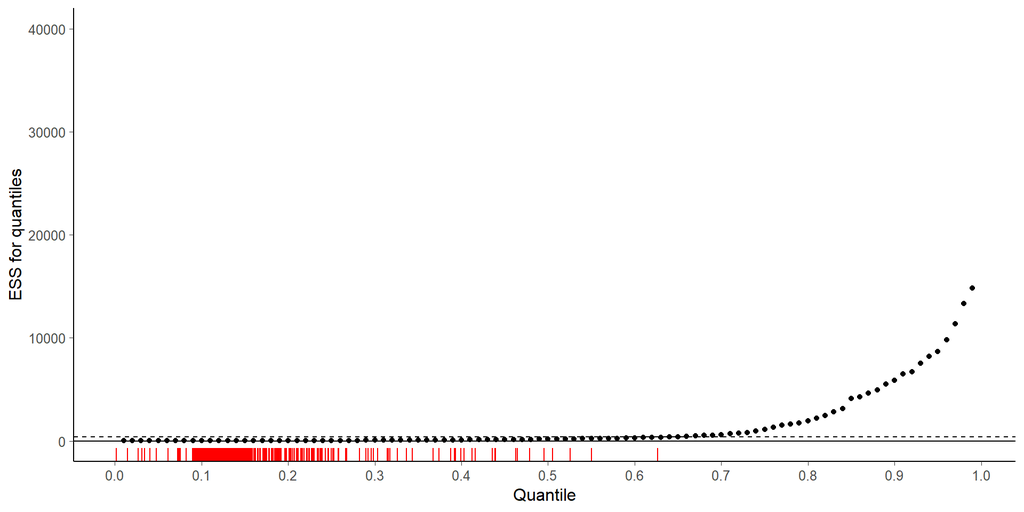

```r
plot_quantile_ess(fit = fit_cp2, par = "tau", nalpha = 100)
```

Several quantile estimates have ESS<400, which raises a doubt that there are convergence problems and we may have significant bias.

Let’s see how the Bulk-ESS and Tail-ESS changes when we use more and more draws.

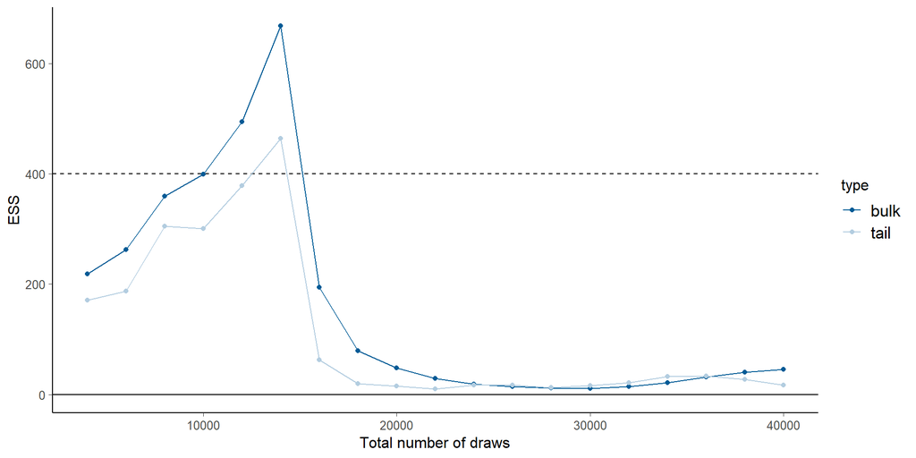

```r
plot_change_ess(fit = fit_cp2, par = "tau")
```

We see that given recommendation that Bulk-ESS>400 and Tail-ESS>400, they are not sufficient to detect convergence problems in this case, even the tail quantile estimates are able to detect these problems.

The rank plot visualisation of `tau` also shows clear sticking and mixing problems.

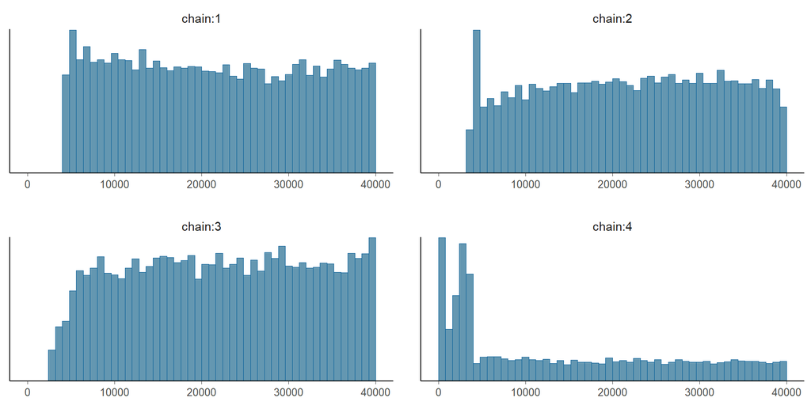

```r
samp_cp2 <- as.array(fit_cp2)
mcmc_hist_r_scale(samp_cp2[, , "tau"])
```

Similar results are obtained for `lp__`, which is closely connected to `tau` for this model.

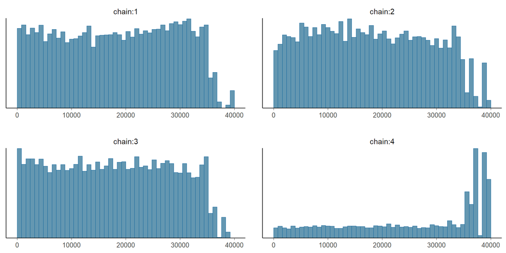

```r
mcmc_hist_r_scale(samp_cp2[, , "lp__"])
```

We may also examine small interval efficiencies for `mu`.

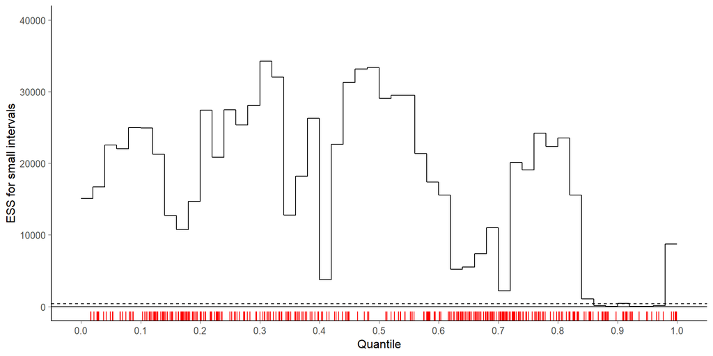

```r
plot_local_ess(fit = fit_cp2, par = "mu", nalpha = 50)
```

There are gaps of poor efficiency which again indicates problems in the mixing of the chains. However, these problems do not occur for any specific range of values of `mu` as was the case for `tau`. This tells us that it’s probably not `mu` with which the sampler has problems, but more likely `tau` or a related quantity.

As we observed divergences, we shouldn’t trust any Monte Carlo standard error (MCSE) estimates as they are likely biased, as well. However, for illustration purposes, we compute the MCSE, tail quantiles and corresponding effective sample sizes for the median of `mu` and `tau`. Comparing to the shorter MCMC run, using 10 times more draws has not reduced the MCSE to one third as would be expected without problems in the mixing of the chains.

```r
round(quantile_mcse(samp_cp2[ , , "mu"], prob = 0.5), 2)
```

```
  mcse  Q05  Q95   Seff
1 0.37 4.22 5.43 173.52
```

```r
round(quantile_mcse(samp_cp2[ , , "tau"], prob = 0.5), 2)
```

```
  mcse  Q05  Q95   Seff
1 0.27 2.38 3.27 174.86
```

#### 4.2.11.2 Centered parameterization with very long chains

For further evidence, let’s check 100 times longer chains than the default. This is not something we would recommend doing in practice, as it is not able to solve any problems with divergences as illustrated below.

```r
fit_cp3 <- stan(
  file = 'eight_schools_cp.stan', data = eight_schools,
  iter = 200000, chains = 4, seed = 483892929, refresh = 0,
  control = list(adapt_delta = 0.95)
)
monitor(fit_cp3)
```

```
Inference for the input samples (4 chains: each with iter = 2e+05; warmup = 1e+05):

             Q5    Q50   Q95   Mean   SD Rhat Bulk_ESS Tail_ESS
mu        -1.10   4.37  9.83   4.37 3.33    1    18335    30265
tau        0.47   2.94 10.04   3.80 3.21    1     2200      769
theta[1]  -1.59   5.73 16.38   6.29 5.69    1    23832   110854
theta[2]  -2.53   4.85 12.76   4.94 4.76    1    27789   136002
theta[3]  -5.06   4.09 11.88   3.87 5.36    1    39355   122761
theta[4]  -2.95   4.68 12.64   4.75 4.86    1    32607   138545
theta[5]  -4.55   3.79 10.77   3.55 4.72    1    34479    44492
theta[6]  -4.16   4.16 11.62   4.01 4.91    1    37000    92227
theta[7]  -1.03   5.92 15.64   6.38 5.16    1    20685    58049
theta[8]  -3.49   4.74 13.51   4.85 5.39    1    36212   125498
lp__     -24.98 -15.15 -2.08 -14.58 6.87    1     2541     1074

For each parameter, Bulk_ESS and Tail_ESS are crude measures of
effective sample size for bulk and tail quantities respectively (good values is
ESS > 400), and Rhat is the potential scale reduction factor on rank normalized
split chains (at convergence, Rhat = 1).
```

```r
res <- monitor_extra(fit_cp3)
print(res)
```

```
Inference for the input samples (4 chains: each with iter = 2e+05; warmup = 1e+05):

           mean se_mean   sd     Q5    Q50   Q95  seff reff sseff zseff zsseff zsreff Rhat sRhat
mu         4.37    0.02 3.33  -1.10   4.37  9.83 18435 0.05 18411 18358  18335   0.05    1     1
tau        3.80    0.03 3.21   0.47   2.94 10.04  9355 0.02  9391  2206   2200   0.01    1     1
theta[1]   6.29    0.03 5.69  -1.59   5.73 16.38 30955 0.08 31120 23846  23832   0.06    1     1
theta[2]   4.94    0.03 4.76  -2.53   4.85 12.76 32922 0.08 33013 27715  27789   0.07    1     1
theta[3]   3.87    0.02 5.36  -5.06   4.09 11.88 53609 0.13 53632 39181  39355   0.10    1     1
theta[4]   4.75    0.02 4.86  -2.95   4.68 12.64 39472 0.10 39723 32535  32607   0.08    1     1
theta[5]   3.55    0.02 4.72  -4.55   3.79 10.77 41358 0.10 41819 34256  34479   0.09    1     1
theta[6]   4.01    0.02 4.91  -4.16   4.16 11.62 45877 0.11 46105 36785  37000   0.09    1     1
theta[7]   6.38    0.03 5.16  -1.03   5.92 15.64 24701 0.06 24691 20682  20685   0.05    1     1
theta[8]   4.85    0.02 5.39  -3.49   4.74 13.51 50166 0.13 50212 36407  36212   0.09    1     1
lp__     -14.58    0.14 6.87 -24.98 -15.15 -2.08  2414 0.01  2410  2545   2541   0.01    1     1
         zRhat zsRhat zfsRhat zfsseff zfsreff tailseff tailreff medsseff medsreff madsseff madsreff
mu           1      1       1   28848    0.07    30265     0.08    16309     0.04    18276     0.05
tau          1      1       1   32860    0.08      769     0.00    10904     0.03    15361     0.04
theta[1]     1      1       1   40586    0.10   110854     0.28    15333     0.04    18846     0.05
theta[2]     1      1       1   41788    0.10   136002     0.34    15135     0.04    18463     0.05
theta[3]     1      1       1   31386    0.08   122761     0.31    16680     0.04    22054     0.06
theta[4]     1      1       1   38705    0.10   138545     0.35    16525     0.04    19038     0.05
theta[5]     1      1       1   37235    0.09    44492     0.11    16593     0.04    18887     0.05
theta[6]     1      1       1   36568    0.09    92227     0.23    16393     0.04    18180     0.05
theta[7]     1      1       1   35129    0.09    58049     0.15    14827     0.04    17370     0.04
theta[8]     1      1       1   38924    0.10   125498     0.31    15431     0.04    16092     0.04
lp__         1      1       1    2942    0.01     1074     0.00    10102     0.03    13775     0.03
```

Rhat, Bulk-ESS and Tail-ESS are not able to detect problems, although relative Bulk-ESS for `tau` is very small 0.5%.

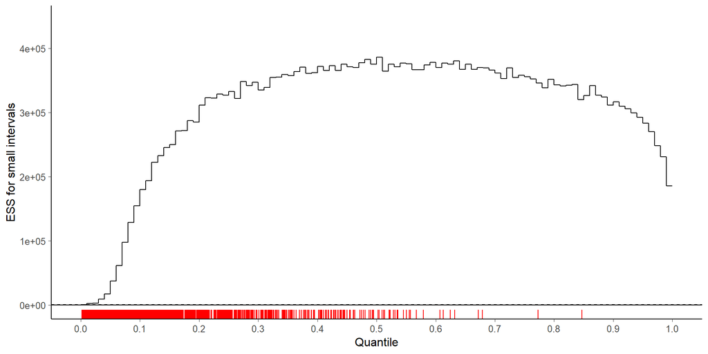

```r
plot_local_ess(fit = fit_cp3, par = "tau", nalpha = 100)
```

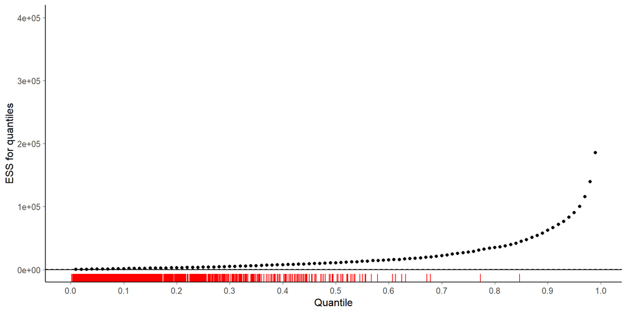

```r
plot_quantile_ess(fit = fit_cp3, par = "tau", nalpha = 100)
```

And the rank plots of `tau` also show sticking and mixing problems for small values of `tau`.

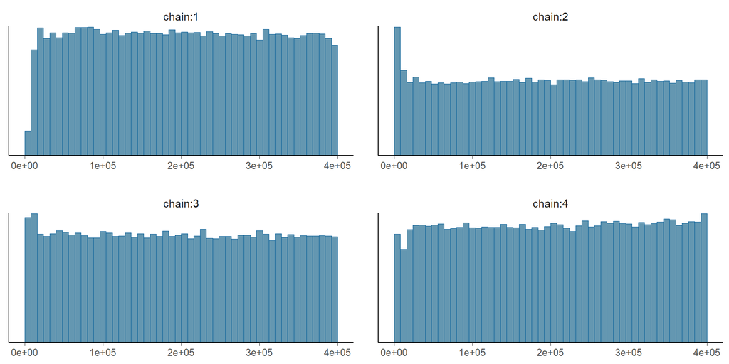

```r
samp_cp3 <- as.array(fit_cp3)
mcmc_hist_r_scale(samp_cp3[, , "tau"])
```

What we do see is an advantage of rank plots over trace plots as even with 100000 draws per chain, rank plots don’t get crowded and the mixing problems of chains is still easy to see.

#### 4.2.11.3 Centered parameterization with very long chains and thinning

Let’s check what happens if we run even longer chains and then thin the draws to reduce autocorrelation. With 400000 iterations per chain, thinning of 200 and 4 chains, we again end up with 4000 iterations as with the default settings.

```r
fit_cp4 <- stan(
  file = 'eight_schools_cp.stan', data = eight_schools,
  iter = 400000, thin = 200, chains = 4, seed = 483892929, refresh = 0,
  control = list(adapt_delta = 0.95)
)
```

We still observe some divergent transitions which potentially bias the results. Apart from that, the convergence diagnostics look ok.

```r
monitor(fit_cp4)
```

```
Inference for the input samples (4 chains: each with iter = 4e+05; warmup = 2e+05):

             Q5    Q50   Q95   Mean   SD Rhat Bulk_ESS Tail_ESS
mu        -0.91   4.46  9.73   4.40 3.24    1     3784     3648
tau        0.46   2.89 10.03   3.75 3.16    1     3625     2447
theta[1]  -1.66   5.63 16.16   6.24 5.74    1     4101     3691
theta[2]  -2.17   4.84 12.61   5.04 4.62    1     3950     3946
theta[3]  -4.54   4.16 11.88   3.98 5.21    1     4121     3819
theta[4]  -3.02   4.73 12.42   4.75 4.83    1     4026     4188
theta[5]  -4.38   3.75 10.56   3.55 4.68    1     3790     3839
theta[6]  -3.76   4.30 11.81   4.18 4.86    1     4057     4059
theta[7]  -0.96   5.91 15.40   6.34 5.00    1     4154     3813
theta[8]  -3.54   4.64 13.48   4.78 5.33    1     4040     3968
lp__     -25.06 -15.02 -1.64 -14.42 6.99    1     3689     2616

For each parameter, Bulk_ESS and Tail_ESS are crude measures of
effective sample size for bulk and tail quantities respectively (good values is
ESS > 400), and Rhat is the potential scale reduction factor on rank normalized
split chains (at convergence, Rhat = 1).
```

```r
res <- monitor_extra(fit_cp4)
print(res)
```

```
Inference for the input samples (4 chains: each with iter = 4e+05; warmup = 2e+05):

           mean se_mean   sd     Q5    Q50   Q95 seff reff sseff zseff zsseff zsreff Rhat sRhat
mu         4.40    0.05 3.24  -0.91   4.46  9.73 3737 0.93  3779  3741   3784   0.95    1     1
tau        3.75    0.05 3.16   0.46   2.89 10.03 4006 1.00  4005  3625   3625   0.91    1     1
theta[1]   6.24    0.09 5.74  -1.66   5.63 16.16 4064 1.02  4071  4096   4101   1.03    1     1
theta[2]   5.04    0.07 4.62  -2.17   4.84 12.61 3924 0.98  3935  3939   3950   0.99    1     1
theta[3]   3.98    0.08 5.21  -4.54   4.16 11.88 4097 1.02  4104  4115   4121   1.03    1     1
theta[4]   4.75    0.08 4.83  -3.02   4.73 12.42 3961 0.99  4006  3971   4026   1.01    1     1
theta[5]   3.55    0.08 4.68  -4.38   3.75 10.56 3720 0.93  3810  3742   3790   0.95    1     1
theta[6]   4.18    0.08 4.86  -3.76   4.30 11.81 3945 0.99  4028  4010   4057   1.01    1     1
theta[7]   6.34    0.08 5.00  -0.96   5.91 15.40 4118 1.03  4127  4144   4154   1.04    1     1
theta[8]   4.78    0.08 5.33  -3.54   4.64 13.48 3968 0.99  3989  4014   4040   1.01    1     1
lp__     -14.42    0.12 6.99 -25.06 -15.02 -1.64 3505 0.88  3563  3686   3689   0.92    1     1
         zRhat zsRhat zfsRhat zfsseff zfsreff tailseff tailreff medsseff medsreff madsseff madsreff
mu           1      1       1    3655    0.91     3648     0.91     4193     1.05     3805     0.95
tau          1      1       1    4095    1.02     2447     0.61     3955     0.99     3815     0.95
theta[1]     1      1       1    4200    1.05     3691     0.92     4115     1.03     3902     0.98
theta[2]     1      1       1    4049    1.01     3946     0.99     3556     0.89     4059     1.01
theta[3]     1      1       1    3810    0.95     3819     0.95     4075     1.02     3810     0.95
theta[4]     1      1       1    3919    0.98     4188     1.05     3496     0.87     3885     0.97
theta[5]     1      1       1    3582    0.90     3839     0.96     3834     0.96     3842     0.96
theta[6]     1      1       1    3882    0.97     4059     1.01     4005     1.00     3820     0.96
theta[7]     1      1       1    4061    1.02     3813     0.95     4259     1.06     3871     0.97
theta[8]     1      1       1    3750    0.94     3968     0.99     4139     1.03     3826     0.96
lp__         1      1       1    3192    0.80     2616     0.65     3835     0.96     3914     0.98
```

Various diagnostic plots of $\tau$ look reasonable as well.

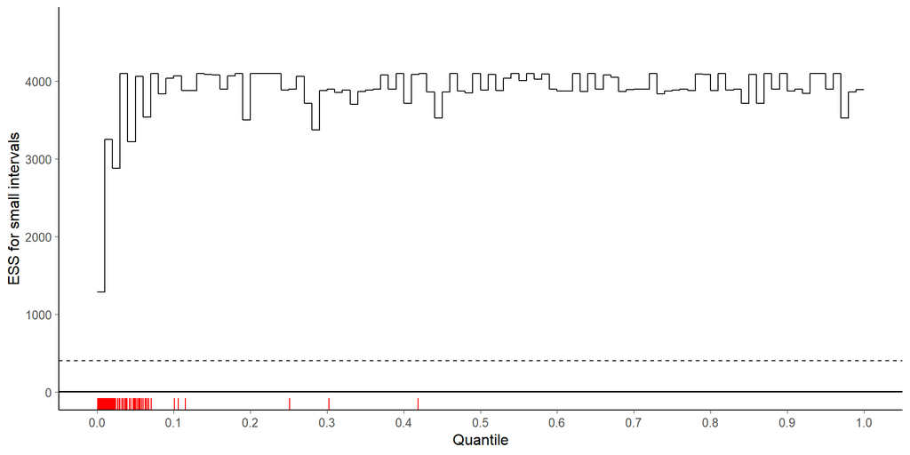

```r
plot_local_ess(fit = fit_cp4, par = "tau", nalpha = 100)
```

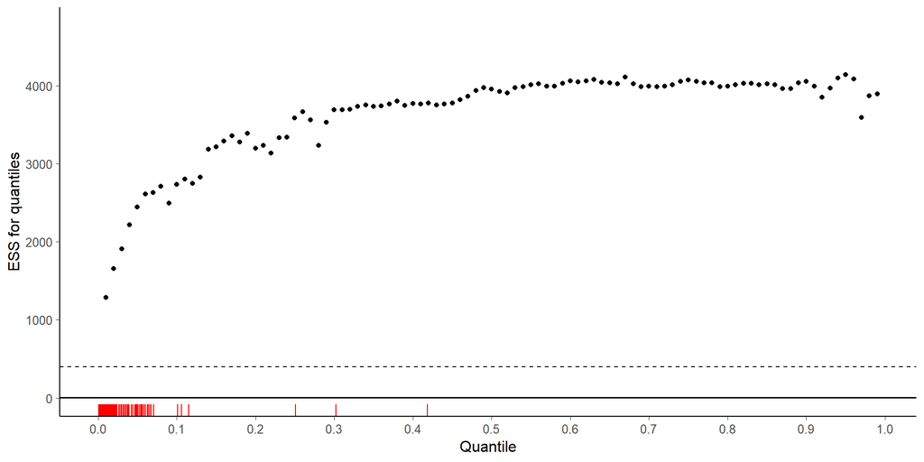

```r
plot_quantile_ess(fit = fit_cp4, par = "tau", nalpha = 100)
```

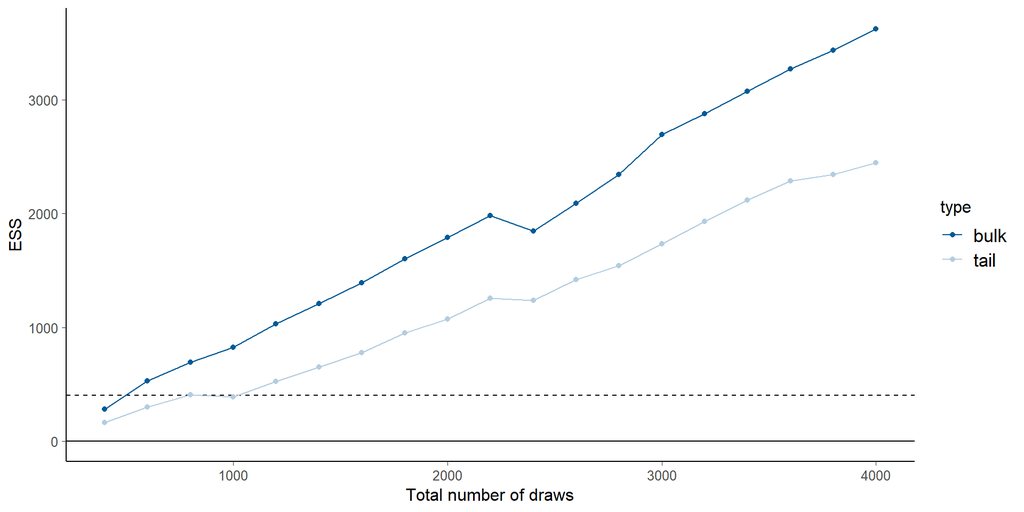

```r
plot_change_ess(fit = fit_cp4, par = "tau")
```

Apparently, after substantial efforts, we got the centered parameterization to yield better results. However, the estimate of $\tau$ is still around 3 sigmas away from the corresponding estimate of the non-centered parameterization.